# Collecting Twitter Data through Academic API

SICSS-Rutgers 2021

This document provides a brief tutorial on communicating with Twitter Academic API using R’s [academictwitteR package](https://joss.theoj.org/papers/10.21105/joss.03272.pdf). The package is built in May, 2021 by Christopher Barrie and Justin Chun-ting Ho.

To be able to run this code:

1. You will need to apply for Twitter Academic API, and have an **approved developer account for academic** **research**. This [link](https://developer.twitter.com/en/use-cases/do-research/academic-research/resources) provides information about the application process.
2. Once your application is approved, you will be able to see your academic project in Twitter’s Developer Portal. You can create a new app or connect an existing app to your project. This will give your **bearer** **token**. You can then use your bearer token to connect to Twitter Academic API using R.
3. You will need the **package academictwitteR** installed and loaded on your computer.

## Getting Started: Installation and Setting Your Bearer Token

Let’s install and/or load the academictwitteR package and some other packages.

```
## install packages
install.packages("academictwitteR")
install.packages("tidyverse")
```

```r
## load packages
library(academictwitteR)
library(tidyverse)
```

You can also install the developer version of the package from its github page. The developer version allows you to access an introductory vignette.

```
devtools::install_github("cjbarrie/academictwitteR", build_vignettes = TRUE)
vignette("academictwitteR-intro")
```

After loading the academictwitteR package, we need to use our bearer token to activate a connection with Twitter’s Academic API. You can find your bearer token in your Developer Portal $\rightarrow$ Projects and Apps $\rightarrow$ Your App $\rightarrow$ Keys and Tokens $\rightarrow$ Authentication Tokens $\rightarrow$ Berarer Token.

For identification,the only token you need is your bearer token.

```
## Assign your bearer token to a character object (you can give any name you want!)
bearer_token <- "enter your bearer token here"
```

What can go wrong in here? We need to make sure that we copy and paste our bearer token here as is, without any additional space character.

## Main Functions

In this part, we will go over the main functions of the academictwitteR package. Let’s begin!

### Search Tweets with Keywords or Hashtags

The workhorse function of the academictwitteR package is the `get_all_tweets` function. This function allows you to collect tweets containing specific keywords and/or hashtags between specified date ranges, avoiding rate limits by sleeping between calls.

How far can we go back in time and how many tweets can we collect? Academic API allows to have free access to the **full history of public conservation**, and allows to collect **10,000,000 tweets per month.**

While exploring this function, we will also discuss two different ways to store tweets.

#### 1. Data Storage in RDS format, returns a data frame (quick/experimental tasks)

The first way of data storage is to assign our function to an object by specifying a file argument. This will return us a data frame object, and save our data frame as an RDS object in our designated folder (our working directory). Let’s illustrate this with some examples, while exploring this function.

In our first example, we are interested in tweets containing the hashtag *#NoWall* OR the hashtag *#NoBanNoWall*. The **OR logic** allows to collect any tweet that contains either keyword/hashtag. How to use this logic with this function? Putting OR between our keywords/hashtags will result in the OR logic.

```r
## assigining to an object called tweets1,will be a data frame object
tweets1 <- get_all_tweets(query = "#NoWall OR #NoBanNoWall",
                              # Any tweet that contains either hashtag
                 start_tweets = "2018-01-01T00:00:00Z", # start date
                 end_tweets = "2018-01-05T00:00:00Z", # end date
                 bearer_token = bearer_token, # bearer token to access Twitter API
                 file = "immigrationtweets1" # name of the resulting RDS file
                 # specificy a file argument - save an RDS format for all the tweets captured with the API call
                 )
```

```
## query: <#NoWall OR #NoBanNoWall>: (tweets captured this page: 489). Total pages queried: 1. Total tweets ingested: 489.
## query: <#NoWall OR #NoBanNoWall>: (tweets captured this page: 306). Total pages queried: 2. Total tweets ingested: 795.
## This is the last page for #NoWall OR #NoBanNoWall : finishing collection.
```

This returns a data frame.

```r
class(tweets1)
```

```
## [1] "data.frame"
```

Let’s take a peek at the first few rows

```r
# head(tweets1) # prints a very long output (you can try out)
tweets1[1,]
```

```
##               source possibly_sensitive      entities.mentions
## 1 Twitter Web Client              FALSE 0, 16, realDonaldTrump
##                                                                                                                      entities.urls
## 1 243, 266, https://t.co/R0ikP7uiNE, https://twitter.com/Dave_in_PDX/status/949067904082894848/photo/1, pic.twitter.com/R0ikP7uiNE
##                                                                                                                                                                                                        entities.hashtags
## 1 32, 52, 73, 109, 132, 142, 194, 202, 214, 229, 42, 59, 84, 127, 141, 154, 201, 213, 228, 242, FactCheck, NoWall, ShutItDown, ImmigrationReform, DACADeal, DreamActNow, Resist, Resistance, TheResistance, FBResistance
##                   entities.annotations in_reply_to_user_id lang
## 1 166, 169, 0.7674, Organization, DEMS            25073877   en
##      conversation_id                 id  author_id
## 1 949066181381632001 949067904082894848 4802303486
##                referenced_tweets
## 1 replied_to, 949066181381632001
##                                                                                                                                                                                                                             context_annotations
## 1 10, 35, Person, Politician, Named people in the world like Nelson Mandela, Politicians in the world, like Joe Biden, 799022225751871488, 799022225751871488, Donald Trump, Donald Trump, US President Donald Trump, US President Donald Trump
##   public_metrics.retweet_count public_metrics.reply_count
## 1                            0                          0
##   public_metrics.like_count public_metrics.quote_count               created_at
## 1                         0                          0 2018-01-04T23:59:55.000Z
##             media_keys
## 1 3_949067899443949568
##                                                                                                                                                                                                                                                                         text
## 1 @realDonaldTrump YOU ARE A LIAR #FactCheck NOT TRUE #NoWall SIMPLY FALSE #ShutItDown WE ALREADY HAVE A WALL. #ImmigrationReform for #DACADeal #DreamActNow I HOPE THE DEMS FIGHT THIS TO THE END. #Resist #Resistance #TheResistance #FBResistance https://t.co/R0ikP7uiNE
##   geo.place_id geo.coordinates.type geo.coordinates.coordinates
## 1         <NA>                 <NA>                        NULL
```

We have a lot of columns. If we want to investigate the data frame, it might be useful to focus on some specific variables. For example, we can specifically check the text column to scan our keywords/hashtags.

```r
head(tweets1$text) # check first few rows for the text column
```

```
## [1] "@realDonaldTrump YOU ARE A LIAR #FactCheck NOT TRUE #NoWall SIMPLY FALSE #ShutItDown WE ALREADY HAVE A WALL. #ImmigrationReform for #DACADeal #DreamActNow I HOPE THE DEMS FIGHT THIS TO THE END. #Resist #Resistance #TheResistance #FBResistance https://t.co/R0ikP7uiNE"
## [2] "Due to discrimination I was abused and cornered to believe that I had not choice. The wall will further marginalize the voiceless and empower their abusers #nowall #trauma #mentalhealth #women #abuse #MeToo #Immigration #ImpeachTrump #love #HumanTrafficking"
## [3] "https://t.co/lq6ruCrHpz #Immigration #NoWall https://t.co/punHgVZEGL"
## [4] "@realDonaldTrump https://t.co/lq6ruCrHpz #Immigration #NoWall"
## [5] "AND YOU THINK IRAN IS MESSED UP. #NOWALL #NOTRUMP https://t.co/0KunhQZEWN"
## [6] "#DumpTrump #Trump #Drumpf #Israel #Palestinians #PalestinianAuthority #Jerusalem #JerusalemEmbassy #SteveBannon #Bannon #NoBanNoWall #SaudiArabia #SAUDIPURGE #IsraelNews https://t.co/kluu0RdpXC"
```

By default, if we don’t change the parameters, the function returns a data frame object with the following 15 columns/fields.

```r
names(tweets1) # check the columns, by default it has 15 columns/fields
```

```
##  [1] "source"              "possibly_sensitive"  "entities"
##  [4] "in_reply_to_user_id" "lang"                "conversation_id"
##  [7] "id"                  "author_id"           "referenced_tweets"
## [10] "context_annotations" "public_metrics"      "created_at"
## [13] "attachments"         "text"                "geo"
```

```r
# str(tweets1) # you can also check the structure, but it is very long!
```

In the second example, we will search tweets containing the *sanctuary city* keyword OR the hashtag *#sanctuarycity*. The **OR logic** again works well for our query. Here, however, we have a keyword, `sanctuary city`, that we would like to capture as an exact phrase. More specifically, suppose that we don’t want tweets containing words sanctuary and city seperately in our tweets. To match exact phrases in our queries, we need to wrap the phrase in double quotes and use single quotes for the general query.

```r
## assigining to an object called tweets2,will be a data frame object
tweets2 <- get_all_tweets(query = '"sanctuary city" OR #sanctuarycity',
                           # Any tweet that contains either keyword/hashtag
                           # wrapping sanctuary city in double quotes, to capture the exact phrase!
                           start_tweets = "2018-01-01T00:00:00Z", # start date
                           end_tweets = "2018-01-02T00:00:00Z", # end date
                           bearer_token = bearer_token, # bearer token to access Twitter API
                           file = "immigrationtweets2" # name of the resulting RDS file
                           # specificy a file argument - save an RDS format for all the tweets captured with the API call
)
```

```
## query: <"sanctuary city" OR #sanctuarycity>: (tweets captured this page: 493). Total pages queried: 1. Total tweets ingested: 493.
## query: <"sanctuary city" OR #sanctuarycity>: (tweets captured this page: 23). Total pages queried: 2. Total tweets ingested: 516.
## This is the last page for "sanctuary city" OR #sanctuarycity : finishing collection.
```

Let’s take a peek at the text column.

```r
head(tweets2$text)
```

```
## [1] "RT @radleybalko: NYC is: \n\n-- 25% black -- largest black population in U.S.\n-- One of our most diverse cities. Whites are now a minority.…"
## [2] "#California @JerryBrownGov #SanctuaryCity  #Sanctuary #tcot #Democrats https://t.co/275qKKJmh6"
## [3] "RT @radleybalko: NYC is: \n\n-- 25% black -- largest black population in U.S.\n-- One of our most diverse cities. Whites are now a minority.…"
## [4] "RT @JudicialWatch: Judicial Watch announced that the Superior Court of California in San Francisco overruled the San Francisco Sheriff's mo…"
## [5] "RT @JudicialWatch: Judicial Watch announced that the Superior Court of California in San Francisco overruled the San Francisco Sheriff's mo…"
## [6] "RT @President1Trump: Welcome to California! New sign reads, OFFICIAL SANCTUARY CITY! Felons, Illegals and MS-13 Welcome! Democrats need the…"
```

```r
## Note: some of the RT texts are truncated.
## To get the full text, get the tweet ID of the referenced tweet, and filter by the id
#tweets2$referenced_tweets[4]
#tweets2 %>% filter(id == "947964401641955328") %>% select(text)
```

What happens if we don’t wrap the phrase *sanctuary city* in double quotes? If we write `"sanctuary city OR #sanctuarycity"`, then the query will search for tweets containing the words *sanctuary* AND *city* OR the hashtag *#sanctuarycity*. You can see the difference from the previous query by running the code chunk below.

```r
## assigining to an object called tweets_2,will be a data frame object
tweets2_diff <- get_all_tweets(query = "sanctuary city OR #sanctuarycity",
                          # Any tweet that contains either keyword/hashtag
                           # wrapping sanctuary city in double quotes, matches the exact phrase!
                           start_tweets = "2018-01-01T00:00:00Z", # start date
                           end_tweets = "2018-01-02T00:00:00Z", # end date
                           bearer_token = bearer_token, # bearer token to access Twitter API
                           file = "immigrationtweets2_diff" # name of the resulting RDS file
                            #specificy a file argument - save an RDS format for all the tweets captured with the API call
)
```

```
## query: <sanctuary city OR #sanctuarycity>: (tweets captured this page: 493). Total pages queried: 1. Total tweets ingested: 493.
## query: <sanctuary city OR #sanctuarycity>: (tweets captured this page: 141). Total pages queried: 2. Total tweets ingested: 634.
## This is the last page for sanctuary city OR #sanctuarycity : finishing collection.
```

```r
head(tweets2_diff$text)
```

```
## [1] "RT @radleybalko: NYC is: \n\n-- 25% black -- largest black population in U.S.\n-- One of our most diverse cities. Whites are now a minority.…"
## [2] "#California @JerryBrownGov #SanctuaryCity  #Sanctuary #tcot #Democrats https://t.co/275qKKJmh6"
## [3] "RT @radleybalko: NYC is: \n\n-- 25% black -- largest black population in U.S.\n-- One of our most diverse cities. Whites are now a minority.…"
## [4] "RT @JudicialWatch: Judicial Watch announced that the Superior Court of California in San Francisco overruled the San Francisco Sheriff's mo…"
## [5] "RT @JudicialWatch: Judicial Watch announced that the Superior Court of California in San Francisco overruled the San Francisco Sheriff's mo…"
## [6] "RT @President1Trump: Welcome to California! New sign reads, OFFICIAL SANCTUARY CITY! Felons, Illegals and MS-13 Welcome! Democrats need the…"
```

```r
tail(tweets2_diff$text)
```

```
## [1] "RT @radleybalko: NYC is: \n\n-- 25% black -- largest black population in U.S.\n-- One of our most diverse cities. Whites are now a minority.…"
## [2] "Name: Tugalg, City of Shores\nin the glade region of the Luaram Glades\nSymbol: Circle\nis close to the divine Tuuom Sanctuary"
## [3] "RT @skb_sara: https://t.co/nrdxbKQkMt ICE confirms that deadly CA fires were set by illegal alien arrested &amp; released 5 times by sanctuary…"
## [4] "RT @radleybalko: NYC is: \n\n-- 25% black -- largest black population in U.S.\n-- One of our most diverse cities. Whites are now a minority.…"
## [5] "RT @JudicialWatch: Judicial Watch announced that the Superior Court of California in San Francisco overruled the San Francisco Sheriff's mo…"
## [6] "Mexico City, Mexico: Release Ely to a sanctuary that can provide her with the love and care she needs! https://t.co/fV918YEhyn https://t.co/uuCGUAwPjA"
```

In our third example, we will collect tweets that contain both the keyword *sanctuary city* as a phrase AND the keyword *Chicago*. Therefore, we will use the **AND logic**. How to use this logic with this function? Putting a space between our keywords will result in the AND logic.

```r
## assigining to an object called tweets3,will be a data frame object
## here we are looking for a limited time, this is okay, we won't crush API
tweets3 <- get_all_tweets(query = '"sanctuary city" Chicago',
                           # Any tweet that contains both keyword/hashtag
                           # wrapping sanctuary city in double quotes, matches the exact phrase
                           start_tweets = "2018-01-01T00:00:00Z", # start date
                           end_tweets = "2018-01-10T00:00:00Z", # end date
                           bearer_token = bearer_token, # bearer token to access Twitter API
                           file = "immigrationtweets3" # name of the resulting RDS file
                           # specificy a file argument - save an RDS format for all the tweets captured with the API call
)
```

```
## query: <"sanctuary city" Chicago>: (tweets captured this page: 129). Total pages queried: 1. Total tweets ingested: 129.
## This is the last page for "sanctuary city" Chicago : finishing collection.
```

Let’s take a peek at the text column.

```r
head(tweets3$text)
```

```
## [1] "RT @CronkiteSays: Mayor Rahm Emanuel announced Chicago will continue to be a welcoming sanctuary city as long as you don't mind dodging a b…"
## [2] "@realDonaldTrump don't believe sanctuary city lover Durbin.  Look what he's done to Chicago"
## [3] "RT @belt_magazine: Emanuel filed a lawsuit against DOJ for its threats to cut off funding due to Chicago’s sanctuary city status. But the m…"
## [4] "RT @belt_magazine: Emanuel filed a lawsuit against DOJ for its threats to cut off funding due to Chicago’s sanctuary city status. But the m…"
## [5] "RT @belt_magazine: Emanuel filed a lawsuit against DOJ for its threats to cut off funding due to Chicago’s sanctuary city status. But the m…"
## [6] "Emanuel filed a lawsuit against DOJ for its threats to cut off funding due to Chicago’s sanctuary city status. But the mayor has decimated services that serve the uninsured and the poor, exactly those people he claims to be protecting. https://t.co/sK2jWMn1gZ"
```

When to use this data storage? This works well if we want to try out something for a short time period, or if we want to experiment with query building.

Now, we will move on with the second way of data stroge. This will be more appropriate if our aim is to collect a larger set of tweets.

#### 2. Storage in JSON files with a data path (larger tasks)

Let’s say we are interested in tweets about immigration with the key word *sanctuary city* OR the hashtag *#sanctuarycity* over a long time period, say 10 years. This API call will run at least several days by paginating over each Twitter page that match our query! For such tasks, the package suggests to store the data as a series of JSON files to mitigate data loss. In practice, we just need to modify our previous code chunks a little bit. We will add two additional arguments to the `get_all_tweets` function: 1) name our data directory where we want to save our data using the data_path argument, 2) don’t bind the tweets in a single data frame by setting bind_tweets argument to FALSE. This is because our data will be stored in multiple JSON files in a folder. Each file will contain approximately up to 500 tweets. We will also remove the file argument we had before. Lastly, we will not assign the function to any object since the function won’t return anything here! Let’s illusrate with an example.

```r
get_all_tweets(query = '"sanctuary city" OR #sanctuarycity',
               # Any tweet that contains either key word/hashtag
               # wrapping sanctuary city in double quotes, matches the exact phrase!
               start_tweets = "2018-01-01T00:00:00Z", # start date
               end_tweets = "2018-01-02T00:00:00Z", # end date
               bearer_token = bearer_token, # bearer token to access Twitter API
               data_path = "immigration_tweets/", # data path where JSON files will be stored
               bind_tweets = FALSE) # don't bind the tweets
```

```
## query: <"sanctuary city" OR #sanctuarycity>: (tweets captured this page: 493). Total pages queried: 1. Total tweets ingested: 493.
## query: <"sanctuary city" OR #sanctuarycity>: (tweets captured this page: 23). Total pages queried: 2. Total tweets ingested: 516.
## This is the last page for "sanctuary city" OR #sanctuarycity : finishing collection.
## Data stored as JSONs: use bind_tweets_json function to bundle into data.frame
```

The collected tweets are now in our data path in the folder *immigration_tweets* as multiple JSON files. Let’s check how many JSON files we have.

```r
## can check the files included
list.files("immigration_tweets") # total 4 json files and one query text file
```

```
## [1] "data_947618995229753346.json"  "data_947630920458268673.json"
## [3] "query"                         "users_947618995229753346.json"
## [5] "users_947630920458268673.json"
```

How to bind our tweets that are stored in multiple JSON files? We need to find a way to convert these JSON files into a format that we can use for our analysis. Good news! There is a very convenient function to do this. We can use a function called `bind_tweet_jsons`. This function will return us a data frame.

```r
immig_data <- bind_tweet_jsons(data_path = "immigration_tweets")
```

Now, we have a data frame.

```r
class(immig_data)
```

```
## [1] "data.frame"
```

```r
## let's take a peek quickly
head(immig_data$text)
```

```
## [1] "RT @radleybalko: NYC is: \n\n-- 25% black -- largest black population in U.S.\n-- One of our most diverse cities. Whites are now a minority.…"
## [2] "RT @radleybalko: NYC is: \n\n-- 25% black -- largest black population in U.S.\n-- One of our most diverse cities. Whites are now a minority.…"
## [3] "RT @radleybalko: NYC is: \n\n-- 25% black -- largest black population in U.S.\n-- One of our most diverse cities. Whites are now a minority.…"
## [4] "RT @radleybalko: NYC is: \n\n-- 25% black -- largest black population in U.S.\n-- One of our most diverse cities. Whites are now a minority.…"
## [5] "Thank-you Governor Hickenlooper...#SanctuaryCity https://t.co/saQcNJt9Dp"
## [6] "I pray that the U.S. never allows Radical Muslim Terrorists to take over as England has. We also need to reverse the \"Sanctuary City\" mindset before U.S. Citizens are treated as end class. https://t.co/u166FI3kEQ"
```

The only thing that changes is the way data is stored. Other than that, everything is the same with our previous examples.

```r
names(immig_data)
```

```
##  [1] "source"              "text"                "created_at"
##  [4] "entities"            "author_id"           "conversation_id"
##  [7] "id"                  "lang"                "public_metrics"
## [10] "possibly_sensitive"  "referenced_tweets"   "geo"
## [13] "context_annotations" "in_reply_to_user_id" "attachments"
```

```r
# str(immig_data)
```

### Collect User Tweets

To collect tweets of a user or set of users between specified date ranges we can use the function `get_user_tweets`. Let’s collect [tweets of some U.S. governors](https://www.nclc.org/images/Governors-Twitter-Handles-2020.pdf) between March, 2021 and June, 2021.

To make our life easier, we can assign multiple users we are interested in to an object called users.

```r
## assign an object to accounts you are interested in
users <- c("GavinNewsom", "GovWhitmer", "GovLauraKelly", "OregonGovBrown")
```

```r
get_user_tweets(users, # users object
               start_tweets = "2021-03-01T00:00:00Z", # start date
               end_tweets = "2021-06-01T00:00:00Z", # end date
               bearer_token = bearer_token, # bearer token
               data_path = "governors_tweets/", # data path where JSON files will be stored
               bind_tweets = FALSE) # don't bind the tweets
```

```
## query: <from:GavinNewsom>: (tweets captured this page: 438). Total pages queried: 1. Total tweets ingested: 438.
## next_token is now NULL for GavinNewsom  moving to next account
## query: <from:GovWhitmer>: (tweets captured this page: 120). Total pages queried: 2. Total tweets ingested: 558.
## next_token is now NULL for GovWhitmer  moving to next account
## query: <from:GovLauraKelly>: (tweets captured this page: 314). Total pages queried: 3. Total tweets ingested: 872.
## next_token is now NULL for GovLauraKelly  moving to next account
## query: <from:OregonGovBrown>: (tweets captured this page: 415). Total pages queried: 4. Total tweets ingested: 1287.
## next_token is now NULL for OregonGovBrown  moving to next account
## No more accounts to captureData stored as JSONs: use bind_tweets_json function to bundle into data.frame
```

These tweets are now in our data path as multiple JSON files in the folder *governors_tweets*. Let’s bind these JSON files.

```r
## can check the files included
list.files("governors_tweets") # total 8 files
```

```
## [1] "data_1366221497241534468.json"  "data_1366435968614498304.json"
## [3] "data_1366445534718930947.json"  "data_1366448173770809346.json"
## [5] "users_1366221497241534468.json" "users_1366435968614498304.json"
## [7] "users_1366445534718930947.json" "users_1366448173770809346.json"
```

```r
## read JSON Files into a data frame
gov_data <- bind_tweet_jsons(data_path = "governors_tweets")
## now we have a data frame
class(gov_data)
```

```
## [1] "data.frame"
```

Let’s take a peek at our data frame

```r
## let's take a peak quickly
gov_data[1,]
```

```
##               source                  id
## 1 Twitter for iPhone 1399478367204823043
##                                                                                                                                                                                                                                                                                                          …
## 1 10, 10, 35, 35, Person, Person, Politician, Politician, Named people in the world like Nelson Mandela, Named people in the world like Nelson Mandela, Politicians in the world, like Joe Biden, Politicians in the world, like Joe Biden, 999344319885524992, 1001868464695332865, 999344319885524992, …
##   author_id lang     conversation_id              referenced_tweets
## 1  11347122   en 1399478367204823043 retweeted, 1399420334693130247
##   public_metrics.retweet_count public_metrics.reply_count
## 1                         2723                          0
##   public_metrics.like_count public_metrics.quote_count possibly_sensitive
## 1                         0                          0              FALSE
##                                                                                                                                             text
## 1 RT @WHCOS: Congrats to @CAgovernor @GavinNewsom and the entire team in CA -- and to @GovLarryHogan and the MD team.  \n\nToday -- the last da…
##                                                             entities.mentions
## 1 3, 23, 35, 84, 9, 34, 47, 98, WHCOS, CAgovernor, GavinNewsom, GovLarryHogan
##        entities.annotations entities.hashtags entities.urls
## 1 71, 72, 0.9234, Place, CA              NULL          NULL
##                 created_at attachments.media_keys attachments.poll_ids place_id
## 1 2021-05-31T21:30:18.000Z                   NULL                 NULL     <NA>
##   in_reply_to_user_id
## 1                <NA>
```

Again, we have 15 columns in total

```r
names(gov_data)
```

```
##  [1] "source"              "id"                  "context_annotations"
##  [4] "author_id"           "lang"                "conversation_id"
##  [7] "referenced_tweets"   "public_metrics"      "possibly_sensitive"
## [10] "text"                "entities"            "created_at"
## [13] "attachments"         "geo"                 "in_reply_to_user_id"
```

This function only returns author IDs, but not the name of user profiles.

```r
table(gov_data$author_id)
```

```
##
##           102071743 1040058893907513344            11347122          3023272478
##                 120                 314                 438                 415
```

We can figure out which author ID belongs to which governor. But, there is an easier way to retrieve governor names. We can use the `get_user_profile()` function to retrieve the user profiles.

```r
## assign an object to retrieve and store author ids
authors <- gov_data$author_id
## use this obect to get user profiles by activating your bearer token
authors_profile <- get_user_profile(authors, bearer_token)
```

```
## Processing from 1 to 100
## Processing from 101 to 200
## Processing from 201 to 300
## Processing from 301 to 400
## Processing from 401 to 500
## Processing from 501 to 600
## Processing from 601 to 700
## Processing from 701 to 800
## Processing from 801 to 900
## Processing from 901 to 1000
## Processing from 1001 to 1100
## Processing from 1101 to 1200
## Processing from 1201 to 1287
```

```r
names(authors_profile)
```

```
##  [1] "protected"         "id"                "profile_image_url"
##  [4] "entities"          "name"              "created_at"
##  [7] "username"          "description"       "public_metrics"
## [10] "location"          "verified"          "url"
## [13] "pinned_tweet_id"
```

If we are only interested in names of the governors, we can subset the name column from our users profile data frame. We can then add this as a column to our original governors data frame.

```r
authors_profile2 <- authors_profile %>% select(name)
gov_data <- cbind(gov_data, authors_profile2)
table(gov_data$name)
```

```
##
##              Gavin Newsom Governor Gretchen Whitmer       Governor Kate Brown
##                       438                       120                       415
##      Governor Laura Kelly
##                       314
```

In the academictwitteR package, currently, there is no build-in function like ts_plot (rtweet package) for plotting tweets as a time series graph. But, we can use ggplot!

```r
## we already loaded tidyverse (includes ggplot2)
# first, need to convert the created_at variable, this format is not appropriate for plotting
head(gov_data$created_at)
```

```
## [1] "2021-05-31T21:30:18.000Z" "2021-05-31T20:01:37.000Z"
## [3] "2021-05-31T18:26:42.000Z" "2021-05-30T23:47:09.000Z"
## [5] "2021-05-29T21:36:10.000Z" "2021-05-29T00:41:44.000Z"
```

```r
## let's name our new variable date
## there are many different ways to do this conversion
gov_data$date <- as.Date(gov_data$created_at)
head(gov_data$date)
```

```
## [1] "2021-05-31" "2021-05-31" "2021-05-31" "2021-05-30" "2021-05-29"
## [6] "2021-05-29"
```

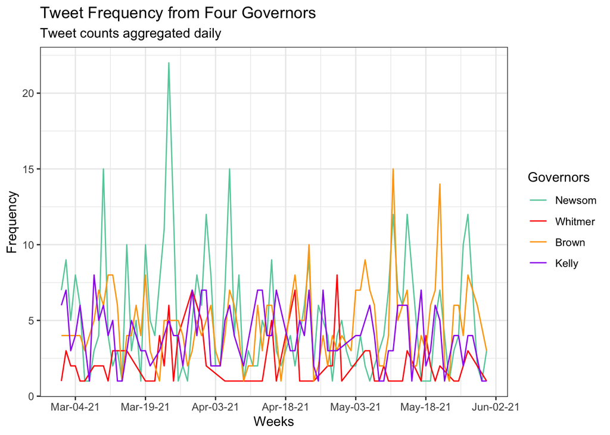

```r
## Now we need to collapse the tweets at the day level for each governor
dat_collapsed_daily <- gov_data %>% group_by(name, date) %>% summarize(n())
dat_collapsed_daily <- dat_collapsed_daily %>% mutate(frequency = `n()`)
## time to plot our tweets
dat_collapsed_daily %>%
  # line below, core component of our plot: `data` and `mapping`.
  ggplot(aes(x = date, y = frequency, group = name, color = name)) + geom_line() +
  # positin new scales for date on the x-axis
  scale_x_date(date_breaks = "15 days", date_labels = "%b-%d-%y") +
  # give a title
  ggtitle("Tweet Frequency from Four Governors",subtitle = "Tweet counts aggregated daily") +
  # change the name of the legend
  labs(color='Governors') +
  # change legend labels/colors
  scale_color_manual(labels = c("Newsom", "Whitmer", "Brown", "Kelly"), values = c("aquamarine3", "red", "orange",
  "purple")) +
  # change the names of x and y axis labels
  theme(plot.title = element_text(face = "bold")) + ylab("Frequency") + xlab("Weeks") +
  # adjust the axis text
  theme(axis.text.x=element_text(angle=60, hjust=1)) +
  # dark-on-light ggplot2 theme (??ggtheme)
  theme_bw()
```